# Mapping analysis progress and plans

Jay Gillenwater

27 April, 2022

# Introduction

This document is a summary of the analysis that has already been done and the analysis that is planned for the Raleigh x Soja mapping population.

# Progress so far

## Data descriptions

### Population structure

The mapping population consists of 151 recombinant inbred line (RIL) soybean genotypes in the $F_4$ generation. Genotypes are identified through numeric codes that range from 1901 to 2105. Codes 2104 and 2105 are the NC Raleigh and PI 424025B (Soja) population parents respectively. The mapping population was grown in 5 locations and three main phenotypes were collected: percent carbon, percent nitrogen, and percent sulfur. The NC Raleigh genotype consistently has been observed to have a lower percent nitrogen and percent than the Soja genotype. This observation was repeated in the current study across all environments.

### Phenotypic distributions

I started by just looking at the overall distributions of the phenotypes, and looked specifically for any obvious outliers or severe departures from normality. In this first set of boxplots, you can see a fairly obvious outlier in the LA environment in all the phenotypes. Because this one sample had a value that was consistently much lower than the rest of the samples, I decided that it was likely a measurement error and removed it from the rest of the analysis. Apart from this one sample, I left the rest of the measurements as they are.

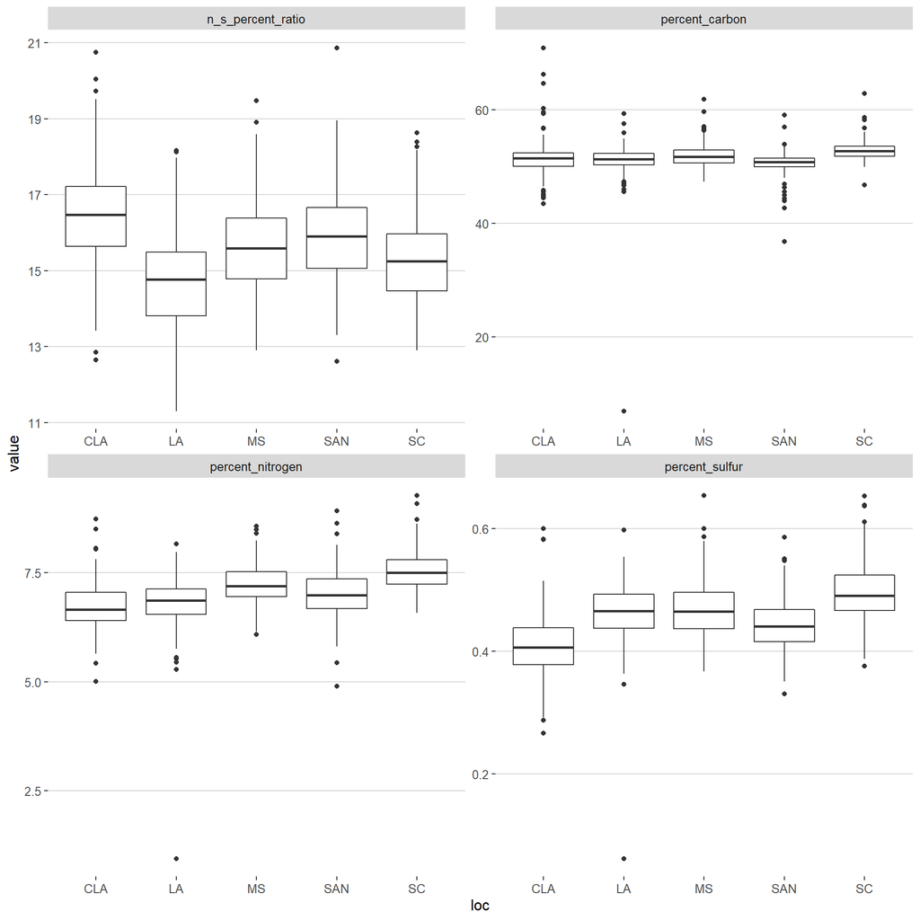

Next I looked at the distributions of the phenotypes, and also where the two parental genotypes fell on these distributions. You can see in the set of plots below that all the phenotypes are roughly normally distributed. Furthermore, you can see that the Raleigh genotype (2104) consistently has lower nitrogen and sulfur content than the Soja parent (2105). Beyond this, the plots also reveal fairly significant transgressive segregation where RILs of the mapping population have higher percent nitrogen and/or higher percent sulfur content than the Soja parent although relatively few genotypes have values in these phenotypes which are lower than those observed in the Raleigh parent. Overall, the distributions for the phenotypes looked close to normal.

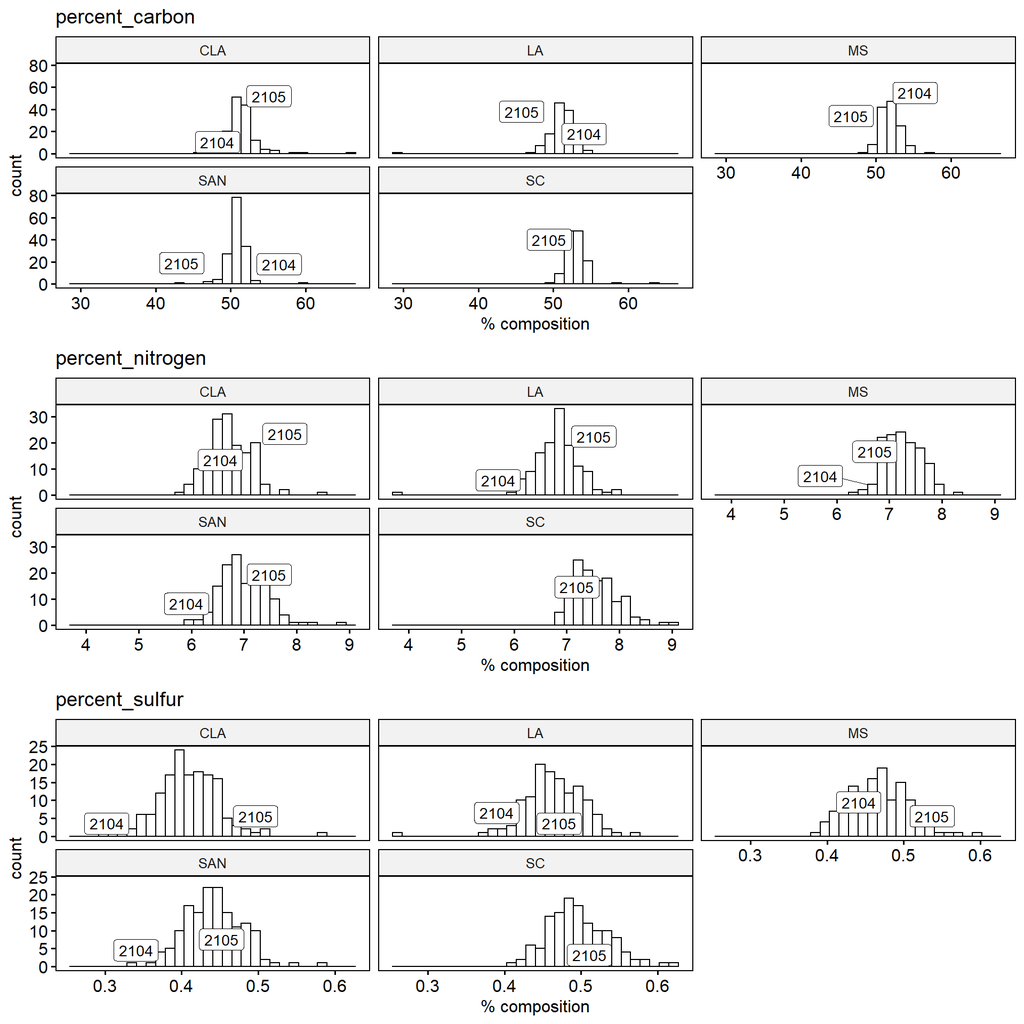

### Genotypic data summary

The genotype data for this mapping population comes from the SoySNP6K beadchip. This data consists of allele calls in an A/B format for 5403 SNPs for each of the 151 genotypes of the mapping population. Two separate genotype files are used in this analysis because three samples were re-genotyped after it was observed that they had poor quality in the first set of data. The data itself is a simple matrix with rows identified by SNP names and columns identified by sample codes. The values of each SNP name x Code intersection are the allelic identity of each SNP for each code. For simplicity, I exported these calls from genomestudio using the A/B format as this would make quality control easier without sacrificing the data quality.

## Linkage mapping

### Data cleaning procedures

#### Phenotypes

By exploring the data with boxplots and histograms I was able to find one likely measurement error. This sample was removed but the rest of the data was kept as-is. Inspection of the phenotypic distributions with histograms showed no obvious departures from normality.

To create a dataset that was ready for use with r/qtl I averaged phenotype measurements for carbon, nirtogen, sulfur, and nitrogen/sulfur ratio both within and across environments. This produces a final dataset of 24 phenotypes for each of the 151 genotypes. There are more “phenotypes” in this data because I plan to run qtl mapping within each environment so that the stability of QTL across environments can be assessed.

#### Genotypes

I first merged the two genotype exports by selecting and appending the appropriate samples from the second genotyping run to the first set. The genotypes then had to be converted to the A/B/H format expected by r/qtl. I did this by replacing all alleles matching the Raleigh parent (code 2104) with the “A” genotype and all alleles matching the Soja parent with the “B” genotype. Heterozygous SNPs were easily identifiable with the “AB” call in the data and these were replaced with the “H” genotype. Missing SNP calls were identified with a “–” code in the genomestudio export. These genotypes were replaced with a “-” indicator to match the r/qtl default. SNPs were then ordered within the data following their chromosome number and physical position. I extracted this information from the SNP names which follow a common naming scheme with various information separated by underscores that can be deciphered easily using regex:

$$[Chromosome\ name]\_[Physical\ position\
(bp)]\_[SNP\ allele\ 1]\_[SNP\ allele\ 2]$$
I ordered markers by chromosome and physical position to make the most use out of the genomic information I already had in hand and under the assumption that it would both make ordering the markers using recombination information easier, and also make potential errors in my cleaning/import process more obvious. Basically, I assumed that markers that lie physically near one another should demonstrate strong linkage and gross deviations from this would likely indicate problems with my data merging/allele coding.

I used several criteria to assess marker and genotype quality using the SNP calls.

**Marker QC**  
1. Remove monomorphic markers.  
2. Remove co-located markers and keep only the marker with the most complete data.  
3. Remove markers with severe segregation distortion.  
4. Remove markers with a lot of missing data (> 5%).

**Genotype QC (after marker QC)**  
1. Remove genotypes with a substantial proportion of missing marker data (> 10%).  
2. Keep only one genotype from genotypic clones.

I performed marker quality control with the [pullCross](https://rdrr.io/cran/ASMap/man/pullCross.html) and [pushCross](https://rdrr.io/cran/ASMap/man/pushCross.html) functions from the ASMap package. These are essentially helpful wrappers for functions from r/qtl to pull aside and put back markers that meet certain criteria. The functions let you filter co located, distorted, and missing markers with the option of easily putting back some (or all) of the markers later on to see how different thresholds affect the final linkage map. This is nicer than pure r/qtl because it lets you work with one object instead of having to make many new ones for each threshold combination.

For genotype statistics, I used the [statGen](https://rdrr.io/cran/ASMap/man/statGen.html) function, also from ASMap. This function lets you calculate many genotype level statistics that can then be used to subset the cross. For finding and fixing genetic clones, I used the [genClones](https://rdrr.io/cran/ASMap/man/genClones.html) and [fixClones](https://rdrr.io/cran/ASMap/man/fixClones.html) functions, respectively. Essentially these two functions first compare the genotypes of all the individuals in the cross and return groups which have very similar genotypes. The fixClones function can then be used to retain only one genotype from each group.

> The genClones function indicated that samples 2104 and 2105 were genetic clones. Maybe sample 2104 was mislabeled in the first genotyping

For the actual mapping I used the mastmap.cross function from ASMap with the Kosambi distance function.

### Final map statistics

The final map has 20 linkage groups corresponding to the 20 chromosomes of the soybean genome. There are a total of 2145 markers with 99.91% of the markers genotyped. 43.85% of the SNP genotypes are homozygous A, 12.78% of the genotypes are heterozygous, and 43.38% of the genotypes are homozygous B. A total of 142 RIL genotypes remain after filtering out genotypes with greater than 10% missing data and retaining only one genotype from sets of genetic clones.

| Chromosome | Number of markers | Average marker spacing (cM) | LG size (cM) |
| --- | --- | --- | --- |
| 1 | 88.00 | 1.460 | 127.360 |
| 2 | 127.00 | 1.580 | 199.010 |
| 3 | 96.00 | 1.430 | 136.230 |
| 4 | 88.00 | 1.530 | 133.160 |
| 5 | 87.00 | 1.480 | 127.170 |
| 6 | 122.00 | 1.440 | 174.080 |
| 7 | 121.00 | 1.290 | 154.810 |
| 8 | 138.00 | 1.530 | 209.000 |
| 9 | 99.00 | 1.340 | 131.400 |
| 10 | 121.00 | 1.310 | 157.130 |
| 11 | 107.00 | 1.860 | 196.980 |
| 12 | 92.00 | 1.400 | 127.170 |
| 13 | 130.00 | 1.590 | 204.590 |
| 14 | 87.00 | 1.640 | 141.440 |
| 15 | 122.00 | 1.430 | 172.820 |
| 16 | 80.00 | 1.440 | 113.860 |
| 17 | 105.00 | 1.650 | 171.950 |
| 18 | 141.00 | 1.370 | 191.280 |
| 19 | 100.00 | 1.690 | 167.220 |
| 20 | 94.00 | 1.700 | 157.800 |
| Average | 107.25 | 1.508 | 159.723 |

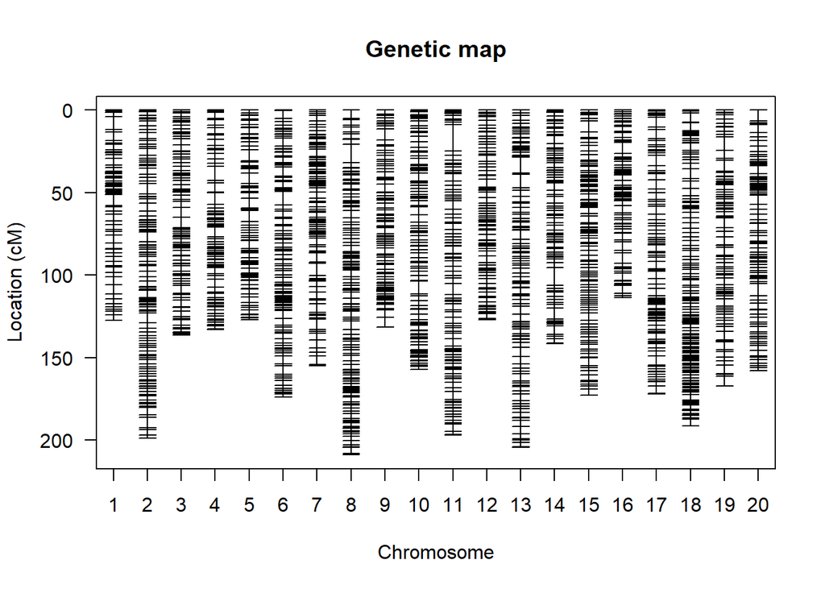

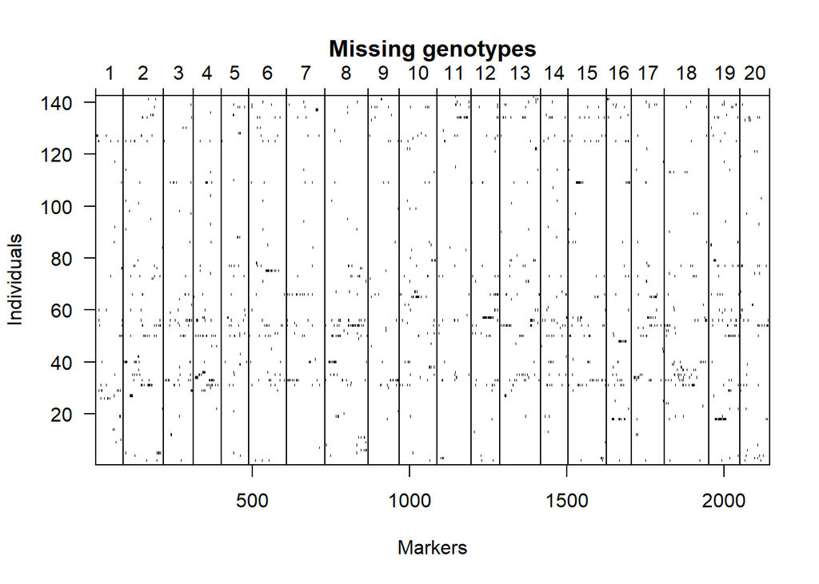

# Planned Analyses

## Mapping

For QTL mapping, I’ll start with simple interval mapping to detect large effect QTL. Likely this will only find a few QTL with large consistent effects. I’ve run this on a couple of the traits already and was able to find a large effect QTL on chr 20 at the site where many qtl have been previously reported for protein/oil so I wasn’t very surprised to see one there for nitrogen content. Simple interval mapping won’t take long, even with the large number of traits so I figured it would be a good starting point for the mapping analysis.

However, for the main portion, I want to use the multiple interval mapping (MIM) capabilities in r/qtl. I want to do this because from the tools available, it offers the best opportunity to find more QTL with smaller effects, and to also explore potential interactions among QTL. There are a few computational challenges with this approach though so I’ll go through them and how I propose to solve them.

Fitting the MIM models requires a permutation test for each phenotype before the model can be fit. Each of these permutation tests takes a while and one has to be done for each phenotype.

Fitting the multiple QTL models requires complete genetic information. This is solved in r/qtl through multiple imputation where gaps in the map are filled in with imputations that are made conditional on the observed marker data. To find the appropriate number of imputations to use, the authors recommend performing some number of imputations, fitting a MIM model, and then increasing the number of imputations and fitting the model again to see if the results change. If the results change, then increase the number of imputations until they don’t. The cost of more imputations is exponentially greater computational time and memory consumption so I want to find a balance between performance and accuracy. This also has to be done for each phenotype.

From experience, I think the permutation tests will be the most time consuming part of this since we’ll have to do a large number (>1000) to meet publication standards. I think the best approach would be to do them in batches by phenotype so that the models can then in turn be fit by phenotype.

### Main points

- The map overall looks good. Lots of markers pass reasonable thresholds and map to reasonable locations and orders. Small marker spacing and also good overall coverage of the genome.
  - The markers for samples 2104 from the first set seem to match 2105 from the second set + the historical records from the 50K chip. Maybe mislabeled sample in the first batch? Otherwise segregation matches what would be expected.
- Initial scans indicate the presence of QTL but detecting additional smaller QTL will need the more time consuming multiple interval mapping techniques.
- Finding the appropriate number of imputations and getting significance thresholds from permutation tests will take time but is straightforward from a technical standpoint (speed is limited mainly by access to computational resources).
- If there is a trait that is a priority, I can “chunk” the analysis to get the results for the more important traits first.
  - Starting with overall averages across environments is also an option.